# IE 360 - HW2

## Raşit Cem Solatay - 2018402072

### 11/05/2022

## 1. Introduction

Aim of this report is to fit a model to predict quarterly unleaded gasoline sales using the data of 2000-2006, and provide forecasts for 2007.

## 2. Data Preparation

Loading necessary packages.

```r
library(data.table)
library(zoo)
library(lubridate)
library(ggplot2)
library(forecast)
library(GGally)
library(MASS)
```

Reading the data, arranging column classes and names, and store it in a data.table object.

```r
df <- read.csv("../datasets/HW2/IE360_Spring22_HW2_data.csv", colClasses = c("character", rep("numeric", 10)),
               col.names = c("Year_Quarter", "UGS", "RNUV", "NLPG", "PU", "PG", "NUGV", "NDGV", "GNPA", "GNPC", "GNP"))
dt <- data.table(df)
df <- NULL
```

Convert date information to yearqtr objects. Add year and quarter columns.

```r
dt[, Year_Quarter:=as.yearqtr(format(Year_Quarter), "%Y_Q%q")]
dt[, Year:=year(Year_Quarter)]
dt[, Quarter := as.factor(quarter(Year_Quarter))]
```

## 3. Plotting the Time Series of UGS

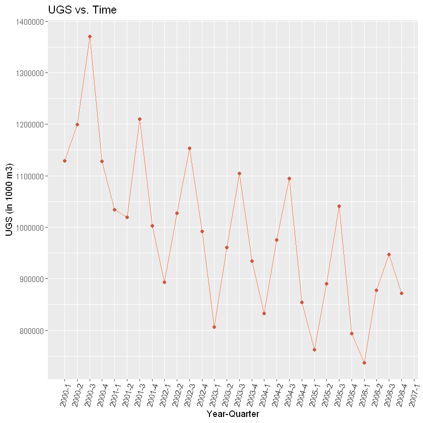

```r
ggplot(dt[Year < 2007], aes(x = Year_Quarter, y = UGS)) + geom_line(color="coral") + geom_point(color="coral3") +
    labs(title = "UGS vs. Time", x = "Year-Quarter", y = "UGS (in 1000 m3)") +
    scale_x_yearqtr(breaks = dt[, Year_Quarter], minor_breaks = dt[, Year_Quarter]) +
    theme(axis.text.x=element_text(angle=75,  hjust=1.4, vjust = 1.4)) +
    scale_y_continuous(breaks = 100000*seq(from = 7, to = 14, by = 1), minor_breaks = 100000*seq(from = 7,to = 14,by = .5))
```

The unleaded gasoline sales seem to be decreasing since 2000 towards the end of 2006. Also there is an obvious seasonal pattern repeated at each 4 data points which is reasonable since it is a quarterly dataset and a year has 4 quarters. Because UGS have a decreasing trend over time, the time series is not stationary with respect to its mean. However, the time series seems to be stationary with respect to its variance since the variance stays at similar levels as far as it is observable on the plot.

## 4. Autocorrelation Functions of UGS

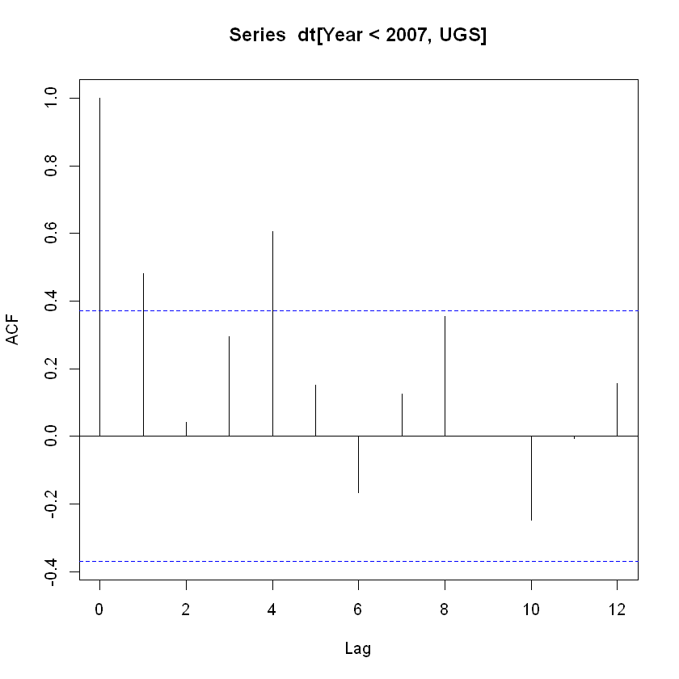

```r
acf(dt[Year < 2007, UGS], 12)
```

Autocorrelation functions get significant values at lag 1 and 4, i.e, exceeding the boundaries. ACF value at lag 1 indicates the presence of trend in the time series while lag 4 refers to seasonality as mentioned before. There is a strong autocorrelation between the same quarter each year. Lags 2, 6, 10 are much lower than the other ones while staying in the boundaries, so we can say that the UGS values may be negatively affected by the UGS values at 2 quarters behind and ahead.

## 5. Model Building

### 5.1. Analyzing Independent Variables

Year and Quarter (as factors to represent seasonality correctly in the linear regression setting) variables were already added to the dataset.

Checking the correlation between variables to see which variables are explaining UGS better and which independent variables are already correlated with each other.

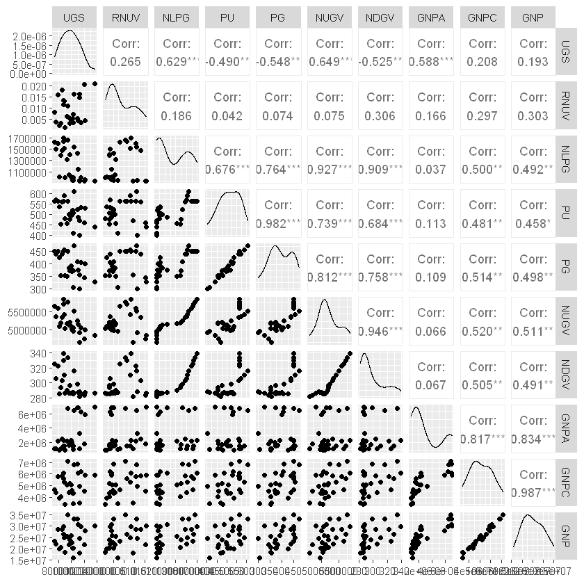

```r
ggpairs(dt[Year < 2007, -c("Year", "Quarter", "Year_Quarter")])
```

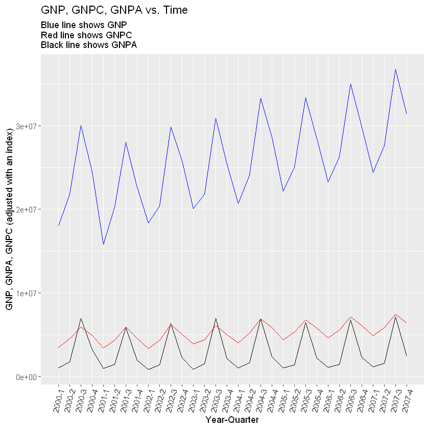

```r
ggplot(dt, aes(x=Year_Quarter)) + geom_line(aes(y=GNPA)) +
    geom_line(aes(y=GNP), color="blue") +
    geom_line(aes(y=GNPC), color="red") +
    labs(title = "GNP, GNPC, GNPA vs. Time", x = "Year-Quarter", y = "GNP, GNPA, GNPC (adjusted with an index)",
        subtitle = "Blue line shows GNP\nRed line shows GNPC\nBlack line shows GNPA") +
    scale_x_yearqtr(breaks = dt[, Year_Quarter], minor_breaks = dt[, Year_Quarter]) +
    theme(axis.text.x=element_text(angle=75,  hjust=1.4, vjust = 1.4))
```

Aggregate and sector based GNP values are showing a very similar seasonality to the UGS has. Therefore, I think that the positive correlation with UGS is the result of the seasonality effect that governs both of them. There is an increasing trend in GNP in contrast of UGS while they have positive correlation. Also the scatter plots of GNP variables versus UGS from the previous chart seems more like randomly distributed. We can say that the raw correlation values may be misleading. But we can try to incorporate these information to support the explaining ability of seasonality variables.

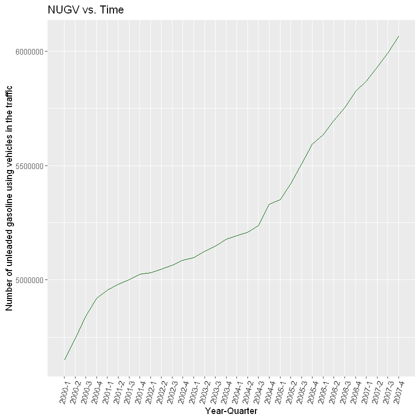

```r
ggplot(dt, aes(x=Year_Quarter)) + geom_line(aes(y=NUGV), color="darkgreen") +
    labs(title = "NUGV vs. Time", x = "Year-Quarter", y = "Number of unleaded gasoline using vehicles in the traffic") +
    scale_x_yearqtr(breaks = dt[, Year_Quarter], minor_breaks = dt[, Year_Quarter]) +
    theme(axis.text.x=element_text(angle=75,  hjust=1.4, vjust = 1.4))
```